# Intro to R

## Data Visualization

There are many different genres of data graphics, with many different variations on each genre. Here are some commonly encountered kinds:

- **scatterplots**: showing relationships between two or more variables
- **distributions**: such as histograms and density curves
- **bar charts**: comparing values of a single variable across groups.

### Scatterplots

The main purpose of the scatterplot is to show the relationship between two variables across several or many cases. Most often, there is a cartesian coordinate system in which the x-axis represents one variable and the y-axis the second variable.

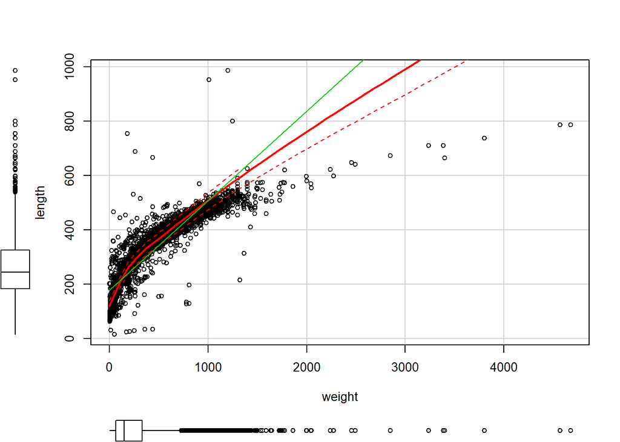

```r
#?scatterplot()

scatterplot(length ~ weight, data = BlackfootFish2)
```

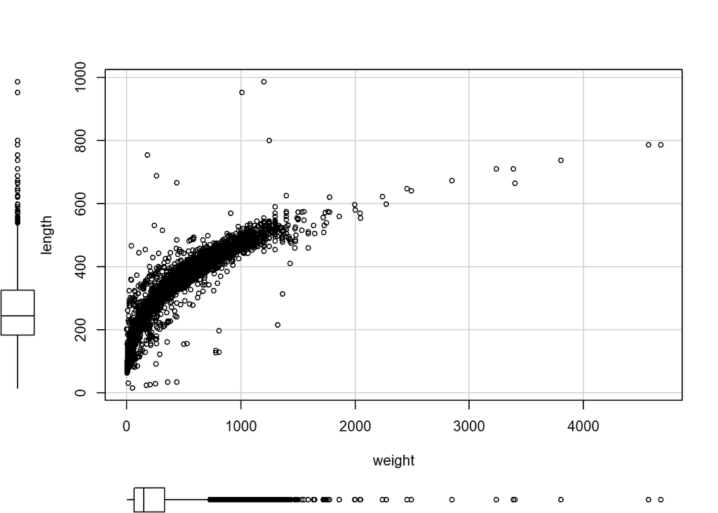

```r
scatterplot(length ~ weight, data = BlackfootFish2, reg.line = FALSE, smooth = FALSE, span = FALSE) ## taking out the trend line (smoother) and 95% CI
```

### Distribution

A histogram shows how many cases fall into a given range of values of a variable.

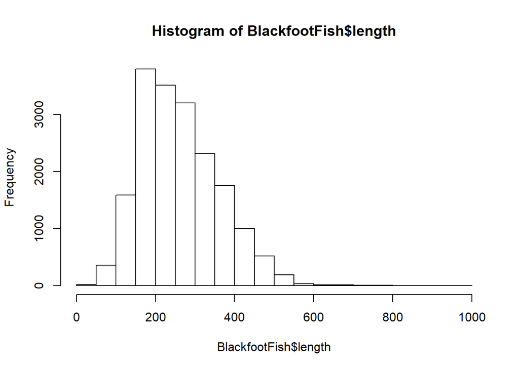

```r
hist(BlackfootFish$length)
```

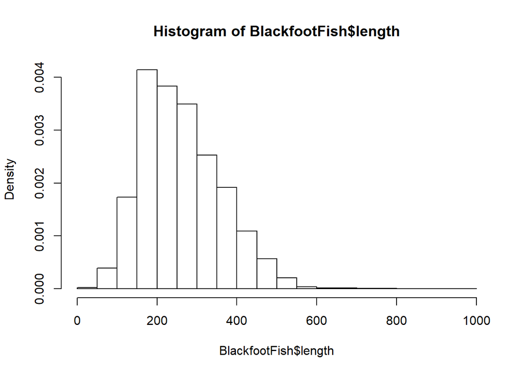

```r
hist(BlackfootFish$length, freq = F) ## converts to a density plot (area adds to 1)
```

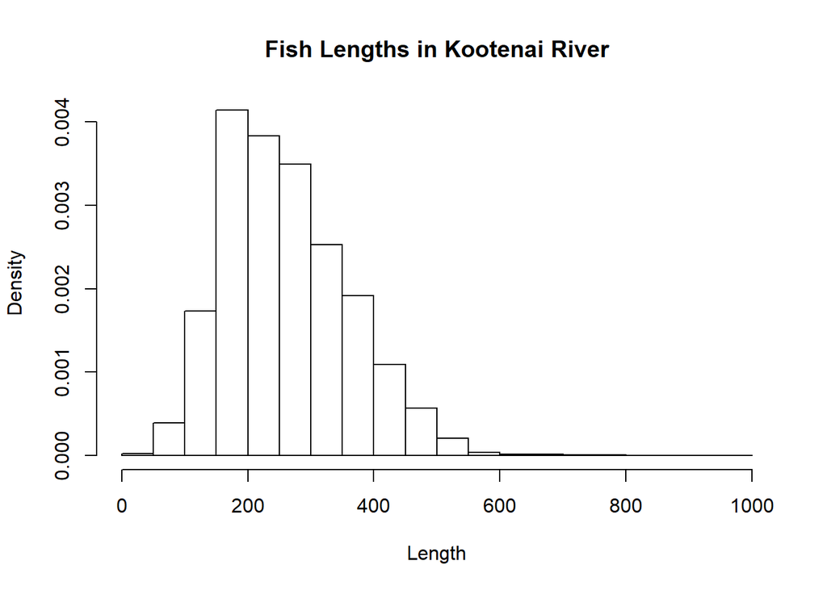

```r
hist(BlackfootFish$length, freq = F, xlab = "Length", main = "Fish Lengths in Kootenai River") ## adds x-axis label and title to plot
```

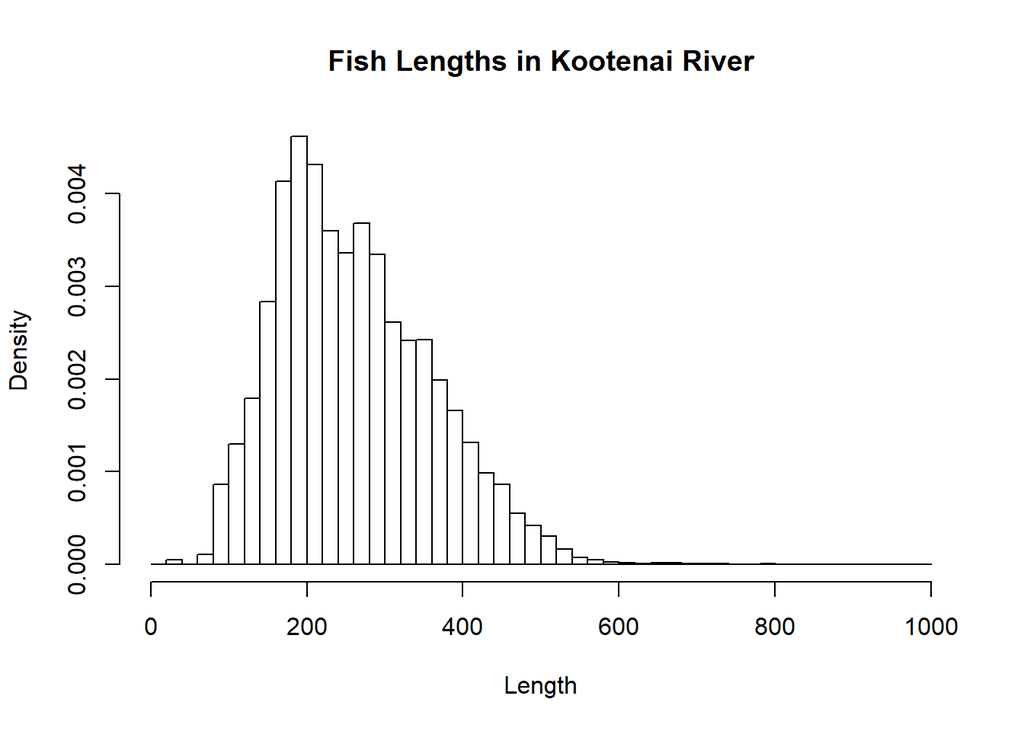

```r
hist(BlackfootFish$length, freq = F, nclass = 50, xlab = "Length", main = "Fish Lengths in Kootenai River") ## changes the number of bins
```

## Bar Charts

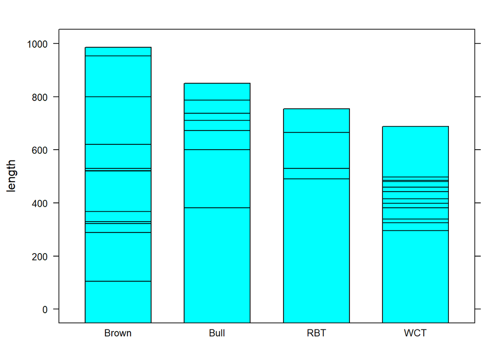

```r
barchart(length ~ species, data = BlackfootFish)
```

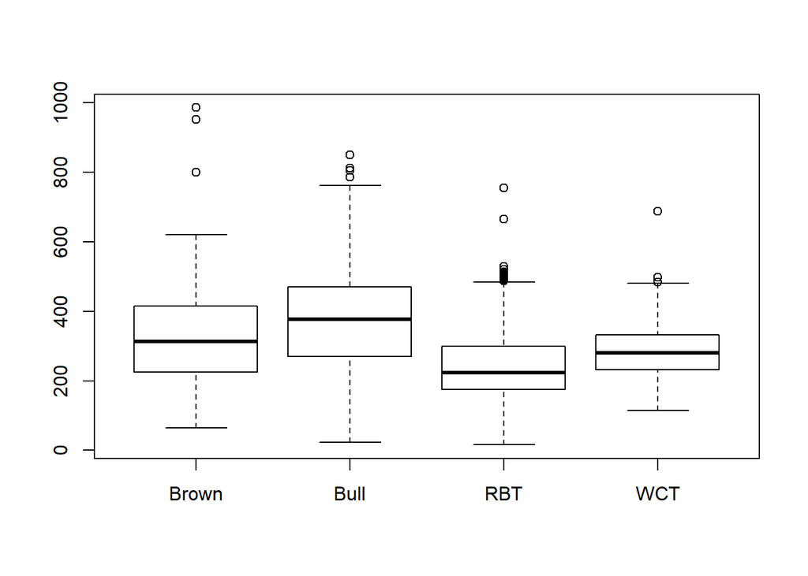

```r
boxplot(length ~ species, data = BlackfootFish)
```

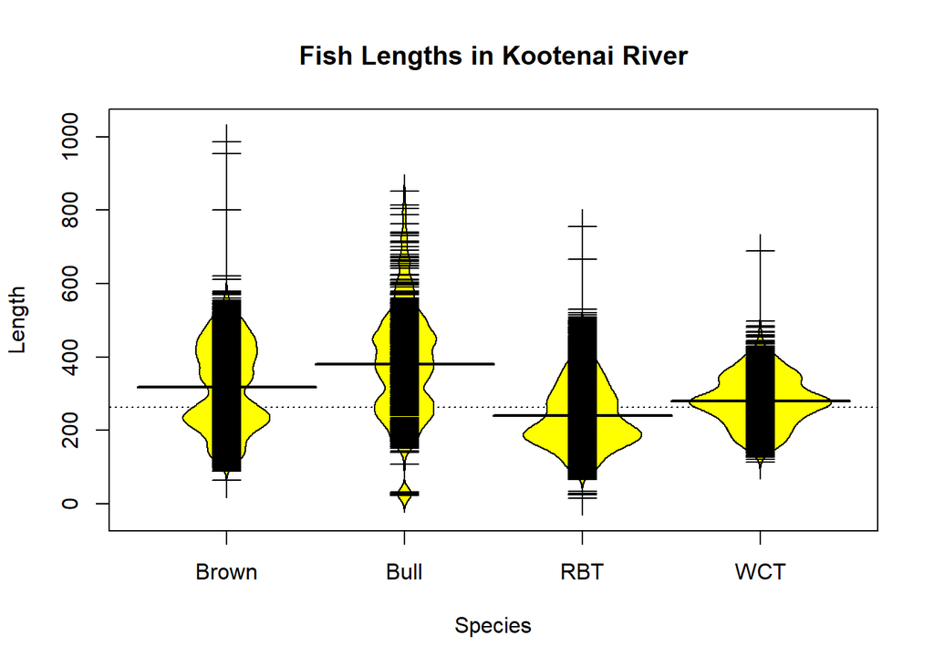

```r
library(beanplot)

beanplot(length ~ species, data = BlackfootFish, method = "jitter", log = "", col = 7, main = "Fish Lengths in Kootenai River", xlab = "Species", ylab = "Length")
```